# STAT5010 Project: Jena Climate Dataset

```r
library(ggplot2)
library(dplyr)
library(car) #for the vif() function
library(zoo) #for plot.zoo
library(anytime) #for anytime
library(tsbox)
library(xts)
library(lubridate)
library(forecast)

jena = read.csv("C:/Users/path/jena_climate_2009_2016.csv")
colnames(jena)
```

1. 'Date.Time'

2. 'p..mbar.'

3. 'T..degC.'

4. 'Tpot..K.'

5. 'Tdew..degC.'

6. 'rh....'

7. 'VPmax..mbar.'

8. 'VPact..mbar.'

9. 'VPdef..mbar.'

10. 'sh..g.kg.'

11. 'H2OC..mmol.mol.'

12. 'rho..g.m..3.'

13. 'wv..m.s.'

14. 'max..wv..m.s.'

15. 'wd..deg.'

```r
jdf = data.frame(
   time = jena$Date.Time , sky_p_mb = jena$p..mbar. , temp_c = jena$T..degC. ,
temp_k = jena$Tpot..K. ,
     dew_point_c = jena$Tdew..degC. , percent_rel_humid = jena$rh.... ,
    max_vapor_p_mb = jena$VPmax..mbar. , actual_vapor_p_mb = jena$VPact..mbar. , deficit_vapor_p_mb = jena$VPdef..mbar. ,
specific_humid_g_per_kg = jena$sh..g.kg. , water_mmol_per_mol = jena$H2OC..mmol.mol. ,
    air_density_grams_per_cube_meter = jena$rho..g.m..3. , wind_speed_ms = jena$wv..m.s. ,
    max_wind_speed_ms = jena$max..wv..m.s. , wind_direction_deg = jena$wd..deg.
                )
head(jdf)
cor(jdf[2:15])
```

| time | sky_p_mb | temp_c | temp_k | dew_point_c | percent_rel_humid | max_vapor_p_mb | actual_vapor_p_mb | deficit_vapor_p_mb | specific_humid_g_per_kg | water_mmol_per_mol | air_density_grams_per_cube_meter | wind_speed_ms | max_wind_speed_ms | wind_direction_deg |
| --- | --- | --- | --- | --- | --- | --- | --- | --- | --- | --- | --- | --- | --- | --- |
| 01.01.2009 00:10:00 | 996.52 | -8.02 | 265.40 | -8.90 | 93.3 | 3.33 | 3.11 | 0.22 | 1.94 | 3.12 | 1307.75 | 1.03 | 1.75 | 152.3 |
| 01.01.2009 00:20:00 | 996.57 | -8.41 | 265.01 | -9.28 | 93.4 | 3.23 | 3.02 | 0.21 | 1.89 | 3.03 | 1309.80 | 0.72 | 1.50 | 136.1 |
| 01.01.2009 00:30:00 | 996.53 | -8.51 | 264.91 | -9.31 | 93.9 | 3.21 | 3.01 | 0.20 | 1.88 | 3.02 | 1310.24 | 0.19 | 0.63 | 171.6 |
| 01.01.2009 00:40:00 | 996.51 | -8.31 | 265.12 | -9.07 | 94.2 | 3.26 | 3.07 | 0.19 | 1.92 | 3.08 | 1309.19 | 0.34 | 0.50 | 198.0 |
| 01.01.2009 00:50:00 | 996.51 | -8.27 | 265.15 | -9.04 | 94.1 | 3.27 | 3.08 | 0.19 | 1.92 | 3.09 | 1309.00 | 0.32 | 0.63 | 214.3 |
| 01.01.2009 01:00:00 | 996.50 | -8.05 | 265.38 | -8.78 | 94.4 | 3.33 | 3.14 | 0.19 | 1.96 | 3.15 | 1307.86 | 0.21 | 0.63 | 192.7 |

|  | sky_p_mb | temp_c | temp_k | dew_point_c | percent_rel_humid | max_vapor_p_mb | actual_vapor_p_mb | deficit_vapor_p_mb | specific_humid_g_per_kg | water_mmol_per_mol | air_density_grams_per_cube_meter | wind_speed_ms | max_wind_speed_ms | wind_direction_deg |
| --- | --- | --- | --- | --- | --- | --- | --- | --- | --- | --- | --- | --- | --- | --- |
| sky_p_mb | 1.000000000 | -0.045374901 | -0.124718259 | -0.066754631 | -0.018351943 | -0.031545643 | -0.054369905 | -0.003401195 | -0.069761824 | -0.069803691 | 0.307640347 | -0.005701278 | -0.007759653 | -0.063258193 |
| temp_c | -0.045374901 | 1.000000000 | 0.996826609 | 0.895708093 | -0.572415668 | 0.951112534 | 0.867673207 | 0.761744284 | 0.866754902 | 0.867176691 | -0.963409622 | -0.004689442 | -0.002870971 | 0.038732020 |
| temp_k | -0.124718259 | 0.996826609 | 1.000000000 | 0.894911210 | -0.567126511 | 0.947292979 | 0.866205344 | 0.756962382 | 0.866533433 | 0.866954908 | -0.981344889 | -0.004195397 | -0.002223944 | 0.043598943 |
| dew_point_c | -0.066754631 | 0.895708093 | 0.894911210 | 1.000000000 | -0.156615337 | 0.799270579 | 0.968343853 | 0.435751535 | 0.967598697 | 0.968044357 | -0.885231841 | -0.008717800 | -0.009090529 | 0.049877412 |
| percent_rel_humid | -0.018351943 | -0.572415668 | -0.567126511 | -0.156615337 | 1.000000000 | -0.615842214 | -0.151493774 | -0.843834769 | -0.150840932 | -0.150969246 | 0.514281828 | -0.005020047 | -0.009921426 | -0.015912236 |
| max_vapor_p_mb | -0.031545643 | 0.951112534 | 0.947292979 | 0.799270579 | -0.615842214 | 1.000000000 | 0.824864835 | 0.875587625 | 0.824459858 | 0.824492740 | -0.901536475 | -0.004018330 | -0.002212826 | -0.009583444 |
| actual_vapor_p_mb | -0.054369905 | 0.867673207 | 0.866205344 | 0.968343853 | -0.151493774 | 0.824864835 | 1.000000000 | 0.449154131 | 0.999851134 | 0.999855678 | -0.850240698 | -0.009599675 | -0.010315774 | 0.018418286 |
| deficit_vapor_p_mb | -0.003401195 | 0.761744284 | 0.756962382 | 0.435751535 | -0.843834769 | 0.875587625 | 0.449154131 | 1.000000000 | 0.448640995 | 0.448689059 | -0.698290153 | 0.001851879 | 0.005317210 | -0.030881057 |
| specific_humid_g_per_kg | -0.069761824 | 0.866754902 | 0.866533433 | 0.967598697 | -0.150840932 | 0.824459858 | 0.999851134 | 0.448640995 | 1.000000000 | 0.999997293 | -0.853324752 | -0.009479046 | -0.010162503 | 0.019376083 |
| water_mmol_per_mol | -0.069803691 | 0.867176691 | 0.866954908 | 0.968044357 | -0.150969246 | 0.824492740 | 0.999855678 | 0.448689059 | 0.999997293 | 1.000000000 | -0.853769118 | -0.009476608 | -0.010157780 | 0.019606883 |
| air_density_grams_per_cube_meter | 0.307640347 | -0.963409622 | -0.981344889 | -0.885231841 | 0.514281828 | -0.901536475 | -0.850240698 | -0.698290153 | -0.853324752 | -0.853769118 | 1.000000000 | 0.003240419 | 0.001085729 | -0.058072352 |
| wind_speed_ms | -0.005701278 | -0.004689442 | -0.004195397 | -0.008717800 | -0.005020047 | -0.004018330 | -0.009599675 | 0.001851879 | -0.009479046 | -0.009476608 | 0.003240419 | 1.000000000 | 0.948476872 | -0.015321871 |
| max_wind_speed_ms | -0.007759653 | -0.002870971 | -0.002223944 | -0.009090529 | -0.009921426 | -0.002212826 | -0.010315774 | 0.005317210 | -0.010162503 | -0.010157780 | 0.001085729 | 0.948476872 | 1.000000000 | -0.014471046 |
| wind_direction_deg | -0.063258193 | 0.038732020 | 0.043598943 | 0.049877412 | -0.015912236 | -0.009583444 | 0.018418286 | -0.030881057 | 0.019376083 | 0.019606883 | -0.058072352 | -0.015321871 | -0.014471046 | 1.000000000 |

```
      time                        sky_p_mb          temp_c
 Min.   :2009-01-01 00:10:00   Min.   : 913.6   Min.   :-23.010
 1st Qu.:2010-12-12 06:22:30   1st Qu.: 984.0   1st Qu.:  3.450
 Median :2012-12-12 12:15:00   Median : 989.4   Median :  9.430
 Mean   :2012-12-20 18:36:58   Mean   : 989.1   Mean   :  9.517
 3rd Qu.:2014-12-12 18:07:30   3rd Qu.: 994.6   3rd Qu.: 15.740
 Max.   :2017-01-01 00:00:00   Max.   :1012.8   Max.   : 37.280
     temp_k       dew_point_c      percent_rel_humid max_vapor_p_mb
 Min.   :250.6   Min.   :-25.010   Min.   : 12.95    Min.   : 0.95
 1st Qu.:277.6   1st Qu.:  0.250   1st Qu.: 65.40    1st Qu.: 7.82
 Median :283.5   Median :  5.460   Median : 79.10    Median :11.83
 Mean   :283.6   Mean   :  5.009   Mean   : 75.91    Mean   :13.73
 3rd Qu.:289.8   3rd Qu.: 10.410   3rd Qu.: 89.10    3rd Qu.:17.91
 Max.   :311.3   Max.   : 21.910   Max.   :100.00    Max.   :63.77
 actual_vapor_p_mb deficit_vapor_p_mb specific_humid_g_per_kg
 Min.   : 0.790    Min.   : 0.000     Min.   : 0.500
 1st Qu.: 6.220    1st Qu.: 0.890     1st Qu.: 3.930
 Median : 9.010    Median : 2.200     Median : 5.690
 Mean   : 9.631    Mean   : 4.099     Mean   : 6.085
 3rd Qu.:12.630    3rd Qu.: 5.310     3rd Qu.: 7.980
 Max.   :26.340    Max.   :46.010     Max.   :16.770
 water_mmol_per_mol air_density_grams_per_cube_meter wind_speed_ms
 Min.   : 0.800     Min.   :1059                     Min.   : 0.000
 1st Qu.: 6.300     1st Qu.:1187                     1st Qu.: 0.990
 Median : 9.120     Median :1213                     Median : 1.770
 Mean   : 9.739     Mean   :1216                     Mean   : 2.144
 3rd Qu.:12.770     3rd Qu.:1242                     3rd Qu.: 2.880
 Max.   :26.690     Max.   :1394                     Max.   :14.090
 max_wind_speed_ms wind_direction_deg
 Min.   : 0.000    Min.   :  0.0
 1st Qu.: 1.760    1st Qu.:122.7
 Median : 3.000    Median :197.8
 Mean   : 3.564    Mean   :174.3
 3rd Qu.: 4.800    3rd Qu.:233.2
 Max.   :20.990    Max.   :360.0
```

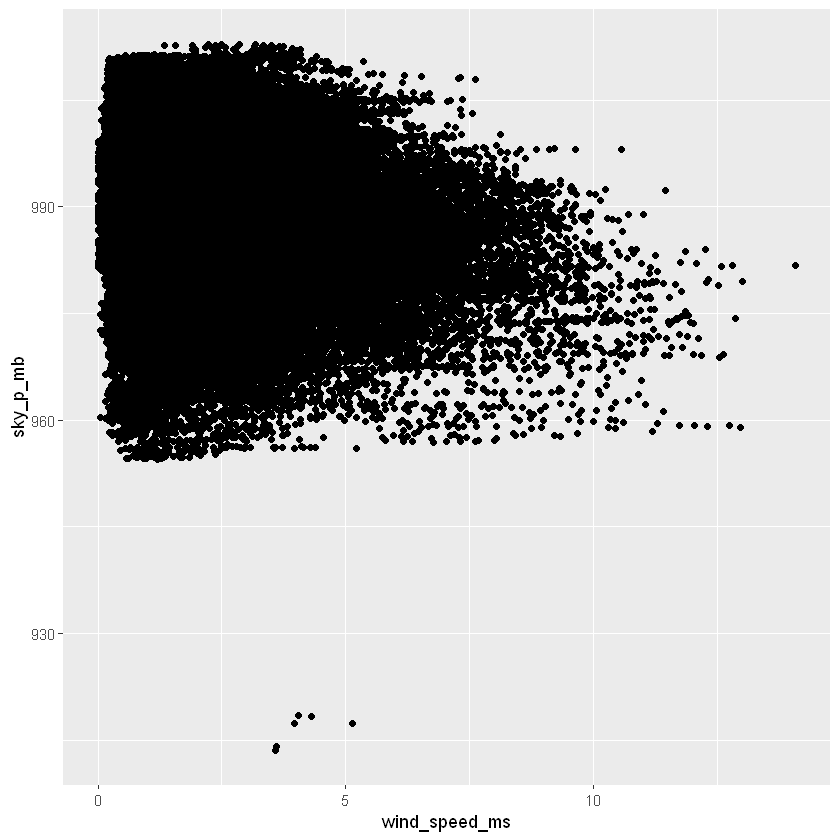

```r
jdf$time <- anytime(jdf$time);
jdf <- na.omit(jdf)
summary(jdf)

ggplot(jdf) +
    geom_point(aes(x = wind_speed_ms, y = sky_p_mb))
```

```r
head(jdf)
cor(jdf[2:15])
```

| time | sky_p_mb | temp_c | temp_k | dew_point_c | percent_rel_humid | max_vapor_p_mb | actual_vapor_p_mb | deficit_vapor_p_mb | specific_humid_g_per_kg | water_mmol_per_mol | air_density_grams_per_cube_meter | wind_speed_ms | max_wind_speed_ms | wind_direction_deg |
| --- | --- | --- | --- | --- | --- | --- | --- | --- | --- | --- | --- | --- | --- | --- |
| 2009-01-01 00:10:00 | 996.52 | -8.02 | 265.40 | -8.90 | 93.3 | 3.33 | 3.11 | 0.22 | 1.94 | 3.12 | 1307.75 | 1.03 | 1.75 | 152.3 |
| 2009-01-01 00:20:00 | 996.57 | -8.41 | 265.01 | -9.28 | 93.4 | 3.23 | 3.02 | 0.21 | 1.89 | 3.03 | 1309.80 | 0.72 | 1.50 | 136.1 |
| 2009-01-01 00:30:00 | 996.53 | -8.51 | 264.91 | -9.31 | 93.9 | 3.21 | 3.01 | 0.20 | 1.88 | 3.02 | 1310.24 | 0.19 | 0.63 | 171.6 |
| 2009-01-01 00:40:00 | 996.51 | -8.31 | 265.12 | -9.07 | 94.2 | 3.26 | 3.07 | 0.19 | 1.92 | 3.08 | 1309.19 | 0.34 | 0.50 | 198.0 |
| 2009-01-01 00:50:00 | 996.51 | -8.27 | 265.15 | -9.04 | 94.1 | 3.27 | 3.08 | 0.19 | 1.92 | 3.09 | 1309.00 | 0.32 | 0.63 | 214.3 |
| 2009-01-01 01:00:00 | 996.50 | -8.05 | 265.38 | -8.78 | 94.4 | 3.33 | 3.14 | 0.19 | 1.96 | 3.15 | 1307.86 | 0.21 | 0.63 | 192.7 |

|  | sky_p_mb | temp_c | temp_k | dew_point_c | percent_rel_humid | max_vapor_p_mb | actual_vapor_p_mb | deficit_vapor_p_mb | specific_humid_g_per_kg | water_mmol_per_mol | air_density_grams_per_cube_meter | wind_speed_ms | max_wind_speed_ms | wind_direction_deg |
| --- | --- | --- | --- | --- | --- | --- | --- | --- | --- | --- | --- | --- | --- | --- |
| sky_p_mb | 1.000000000 | -0.03320378 | -0.11188079 | -0.07106770 | -0.060961110 | -0.003457012 | -0.036997647 | 0.02614440 | -0.052128217 | -0.052259087 | 0.2965111 | -0.18312259 | -0.17450329 | -0.079349742 |
| temp_c | -0.033203776 | 1.00000000 | 0.99688558 | 0.90323894 | -0.553033720 | 0.946492325 | 0.875080939 | 0.75252002 | 0.874117765 | 0.874527914 | -0.9631651 | 0.07502572 | 0.10924392 | 0.020463769 |
| temp_k | -0.111880791 | 0.99688558 | 1.00000000 | 0.90359226 | -0.545198813 | 0.941522735 | 0.873105412 | 0.74633014 | 0.873356408 | 0.873773569 | -0.9809868 | 0.08915223 | 0.12247722 | 0.026718450 |
| dew_point_c | -0.071067701 | 0.90323894 | 0.90359226 | 1.00000000 | -0.150349971 | 0.796476802 | 0.965210164 | 0.43761252 | 0.964638575 | 0.965095425 | -0.8961368 | -0.05794999 | -0.04282137 | 0.037900445 |
| percent_rel_humid | -0.060961110 | -0.55303372 | -0.54519881 | -0.15034997 | 1.000000000 | -0.609735866 | -0.151165629 | -0.83750278 | -0.150022442 | -0.150093712 | 0.4849828 | -0.30290978 | -0.35368912 | 0.008436055 |
| max_vapor_p_mb | -0.003457012 | 0.94649233 | 0.94152274 | 0.79647680 | -0.609735866 | 1.000000000 | 0.828009718 | 0.87760475 | 0.827434278 | 0.827439019 | -0.8910259 | 0.07694095 | 0.10880217 | -0.025997272 |
| actual_vapor_p_mb | -0.036997647 | 0.87508094 | 0.87310541 | 0.96521016 | -0.151165629 | 0.828009718 | 1.000000000 | 0.45786813 | 0.999854778 | 0.999858052 | -0.8540835 | -0.08149311 | -0.07078459 | 0.005871587 |
| deficit_vapor_p_mb | 0.026144402 | 0.75252002 | 0.74633014 | 0.43761252 | -0.837502780 | 0.877604751 | 0.457868130 | 1.00000000 | 0.457079662 | 0.457084353 | -0.6825304 | 0.19166610 | 0.23302629 | -0.046236310 |
| specific_humid_g_per_kg | -0.052128217 | 0.87411776 | 0.87335641 | 0.96463857 | -0.150022442 | 0.827434278 | 0.999854778 | 0.45707966 | 1.000000000 | 0.999997381 | -0.8570377 | -0.07859440 | -0.06812460 | 0.007204019 |
| water_mmol_per_mol | -0.052259087 | 0.87452791 | 0.87377357 | 0.96509542 | -0.150093712 | 0.827439019 | 0.999858052 | 0.45708435 | 0.999997381 | 1.000000000 | -0.8574998 | -0.07849367 | -0.06799383 | 0.007421436 |
| air_density_grams_per_cube_meter | 0.296511105 | -0.96316505 | -0.98098683 | -0.89613678 | 0.484982755 | -0.891025903 | -0.854083460 | -0.68253038 | -0.857037686 | -0.857499822 | 1.0000000 | -0.11191025 | -0.14157120 | -0.044800403 |
| wind_speed_ms | -0.183122594 | 0.07502572 | 0.08915223 | -0.05794999 | -0.302909781 | 0.076940952 | -0.081493109 | 0.19166610 | -0.078594401 | -0.078493669 | -0.1119102 | 1.00000000 | 0.95717104 | -0.063436505 |
| max_wind_speed_ms | -0.174503294 | 0.10924392 | 0.12247722 | -0.04282137 | -0.353689120 | 0.108802174 | -0.070784589 | 0.23302629 | -0.068124603 | -0.067993829 | -0.1415712 | 0.95717104 | 1.00000000 | -0.007437650 |
| wind_direction_deg | -0.079349742 | 0.02046377 | 0.02671845 | 0.03790044 | 0.008436055 | -0.025997272 | 0.005871587 | -0.04623631 | 0.007204019 | 0.007421436 | -0.0448004 | -0.06343651 | -0.00743765 | 1.000000000 |

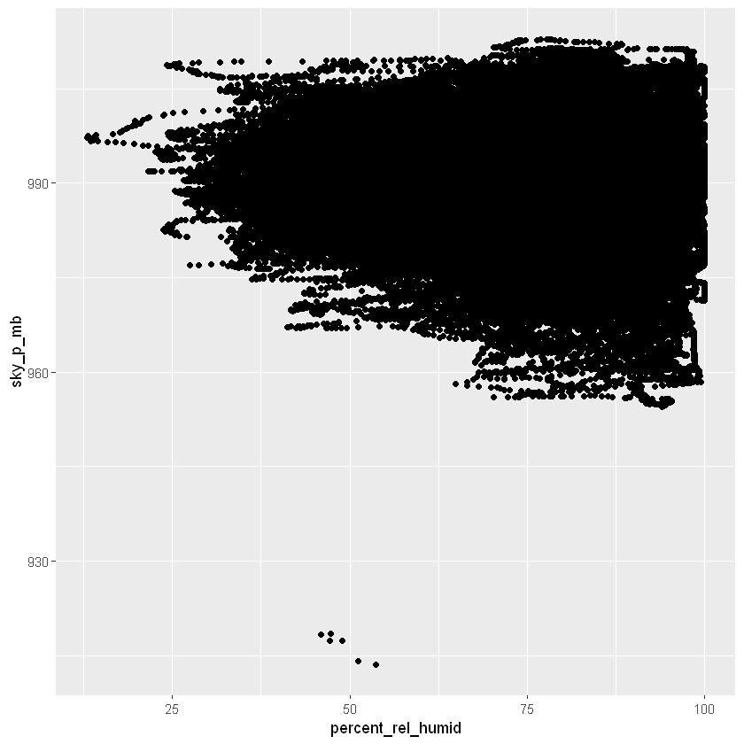

```r
ggplot(jdf) +
    geom_point(aes(x = percent_rel_humid, y = sky_p_mb))
```

```r
lm_jdf = lm(sky_p_mb ~ temp_c + temp_k + dew_point_c + percent_rel_humid + max_vapor_p_mb + actual_vapor_p_mb +
            deficit_vapor_p_mb + specific_humid_g_per_kg + water_mmol_per_mol + air_density_grams_per_cube_meter +
            +wind_speed_ms+ max_wind_speed_ms + wind_direction_deg, data = jdf)
summary(lm_jdf)
```

```
Call:
lm(formula = sky_p_mb ~ temp_c + temp_k + dew_point_c + percent_rel_humid +
    max_vapor_p_mb + actual_vapor_p_mb + deficit_vapor_p_mb +
    specific_humid_g_per_kg + water_mmol_per_mol + air_density_grams_per_cube_meter +
    +wind_speed_ms + max_wind_speed_ms + wind_direction_deg,
    data = jdf)

Residuals:
     Min       1Q   Median       3Q      Max
-1.11492 -0.05678 -0.01084  0.04483  3.16114

Coefficients:
                                   Estimate Std. Error   t value Pr(>|t|)
(Intercept)                       3.306e+03  2.868e+00  1152.634  < 2e-16 ***
temp_c                            1.041e+01  6.033e-03  1726.247  < 2e-16 ***
temp_k                           -9.415e+00  8.291e-03 -1135.569  < 2e-16 ***
dew_point_c                       8.834e-02  7.207e-04   122.573  < 2e-16 ***
percent_rel_humid                -3.059e-03  1.122e-04   -27.272  < 2e-16 ***
max_vapor_p_mb                   -1.320e+00  4.921e-02   -26.823  < 2e-16 ***
actual_vapor_p_mb                -2.145e+00  4.972e-02   -43.151  < 2e-16 ***
deficit_vapor_p_mb                1.223e+00  4.923e-02    24.846  < 2e-16 ***
specific_humid_g_per_kg           6.529e+00  6.388e-02   102.215  < 2e-16 ***
water_mmol_per_mol               -7.752e-01  4.382e-02   -17.690  < 2e-16 ***
air_density_grams_per_cube_meter  2.099e-01  4.772e-04   439.831  < 2e-16 ***
wind_speed_ms                     4.269e-03  5.633e-04     7.578 3.52e-14 ***
max_wind_speed_ms                -3.554e-04  3.760e-04    -0.945    0.345
wind_direction_deg                1.966e-05  2.955e-06     6.654 2.87e-11 ***
---
Signif. codes:  0 '***' 0.001 '**' 0.01 '*' 0.05 '.' 0.1 ' ' 1

Residual standard error: 0.1002 on 166016 degrees of freedom
Multiple R-squared:  0.9999,	Adjusted R-squared:  0.9999
F-statistic: 9.269e+07 on 13 and 166016 DF,  p-value: < 2.2e-16
```

```r
vif(lm_jdf)
kappa(lm_jdf)
```

**temp_c**

45439.2511077044

**temp_k**

87266.7063797496

**dew_point_c**

425.329021930508

**percent_rel_humid**

55.2833419863095

**max_vapor_p_mb**

2544175.34190047

**actual_vapor_p_mb**

754976.141558807

**deficit_vapor_p_mb**

1012691.03668438

**specific_humid_g_per_kg**

501368.860855636

**water_mmol_per_mol**

599972.578030491

**air_density_grams_per_cube_meter**

6405.04891693724

**wind_speed_ms**

12.7244241214876

**max_wind_speed_ms**

13.1169771671346

**wind_direction_deg**

1.08302733590183

12818770.9945613

> Clearly, there are too many variables. I can not test every single model combination by hand because there are around 6.2 billion. Let's test with max_wind_speed_ms vs. without. SInce there is a direct relationship between wind speed and max wind speed, it should be a fine choice.

```r
lm_jdf_no = lm(sky_p_mb ~ temp_c + temp_k + dew_point_c + percent_rel_humid + max_vapor_p_mb + actual_vapor_p_mb +
            deficit_vapor_p_mb + specific_humid_g_per_kg + water_mmol_per_mol + air_density_grams_per_cube_meter +
            + wind_speed_ms + wind_direction_deg, data = jdf)
summary(lm_jdf_no)
```

```
Call:
lm(formula = sky_p_mb ~ temp_c + temp_k + dew_point_c + percent_rel_humid +
    max_vapor_p_mb + actual_vapor_p_mb + deficit_vapor_p_mb +
    specific_humid_g_per_kg + water_mmol_per_mol + air_density_grams_per_cube_meter +
    +wind_speed_ms + wind_direction_deg, data = jdf)

Residuals:
     Min       1Q   Median       3Q      Max
-1.11503 -0.05680 -0.01084  0.04479  3.16128

Coefficients:
                                   Estimate Std. Error   t value Pr(>|t|)
(Intercept)                       3.306e+03  2.868e+00  1152.635  < 2e-16 ***
temp_c                            1.041e+01  6.033e-03  1726.250  < 2e-16 ***
temp_k                           -9.415e+00  8.291e-03 -1135.571  < 2e-16 ***
dew_point_c                       8.833e-02  7.207e-04   122.570  < 2e-16 ***
percent_rel_humid                -3.055e-03  1.121e-04   -27.256  < 2e-16 ***
max_vapor_p_mb                   -1.320e+00  4.921e-02   -26.827  < 2e-16 ***
actual_vapor_p_mb                -2.145e+00  4.972e-02   -43.151  < 2e-16 ***
deficit_vapor_p_mb                1.223e+00  4.923e-02    24.849  < 2e-16 ***
specific_humid_g_per_kg           6.528e+00  6.387e-02   102.212  < 2e-16 ***
water_mmol_per_mol               -7.745e-01  4.381e-02   -17.677  < 2e-16 ***
air_density_grams_per_cube_meter  2.099e-01  4.772e-04   439.834  < 2e-16 ***
wind_speed_ms                     3.762e-03  1.733e-04    21.710  < 2e-16 ***
wind_direction_deg                1.917e-05  2.908e-06     6.591 4.39e-11 ***
---
Signif. codes:  0 '***' 0.001 '**' 0.01 '*' 0.05 '.' 0.1 ' ' 1

Residual standard error: 0.1002 on 166017 degrees of freedom
Multiple R-squared:  0.9999,	Adjusted R-squared:  0.9999
F-statistic: 1.004e+08 on 12 and 166017 DF,  p-value: < 2.2e-16
```

```r
anova(lm_jdf_no, lm_jdf)
```

| Res.Df | RSS | Df | Sum of Sq | F | Pr(>F) |
| --- | --- | --- | --- | --- | --- |
| 166017 | 1665.222 | NA | NA | NA | NA |
| 166016 | 1665.213 | 1 | 0.008961107 | 0.8933915 | 0.3445613 |

```r
anova(lm_jdf)
```

|  | Df | Sum Sq | Mean Sq | F value | Pr(>F) |
| --- | --- | --- | --- | --- | --- |
| temp_c | 1 | 1.332694e+04 | 1.332694e+04 | 1.328650e+06 | 0.000000e+00 |
| temp_k | 1 | 1.206318e+07 | 1.206318e+07 | 1.202658e+09 | 0.000000e+00 |
| dew_point_c | 1 | 6.189326e+01 | 6.189326e+01 | 6.170546e+03 | 0.000000e+00 |
| percent_rel_humid | 1 | 1.410805e+00 | 1.410805e+00 | 1.406524e+02 | 1.975418e-32 |
| max_vapor_p_mb | 1 | 8.000881e+02 | 8.000881e+02 | 7.976604e+04 | 0.000000e+00 |
| actual_vapor_p_mb | 1 | 3.129173e+02 | 3.129173e+02 | 3.119678e+04 | 0.000000e+00 |
| deficit_vapor_p_mb | 1 | 6.444216e-02 | 6.444216e-02 | 6.424662e+00 | 1.125554e-02 |
| specific_humid_g_per_kg | 1 | 6.246270e+03 | 6.246270e+03 | 6.227316e+05 | 0.000000e+00 |
| water_mmol_per_mol | 1 | 4.846847e+02 | 4.846847e+02 | 4.832140e+04 | 0.000000e+00 |
| air_density_grams_per_cube_meter | 1 | 1.944615e+03 | 1.944615e+03 | 1.938714e+05 | 0.000000e+00 |
| wind_speed_ms | 1 | 4.488037e+00 | 4.488037e+00 | 4.474418e+02 | 3.516667e-99 |
| max_wind_speed_ms | 1 | 5.823173e-04 | 5.823173e-04 | 5.805503e-02 | 8.095972e-01 |
| wind_direction_deg | 1 | 4.440635e-01 | 4.440635e-01 | 4.427161e+01 | 2.867149e-11 |
| Residuals | 166016 | 1.665213e+03 | 1.003044e-02 | NA | NA |

```r
w <- abs(rstudent(lm_jdf_no)) < 3 & abs(cooks.distance(lm_jdf_no)) < 4/nrow(lm_jdf_no$model)
lm_jdf_no <- update(lm_jdf_no, weights=as.numeric(w))
```

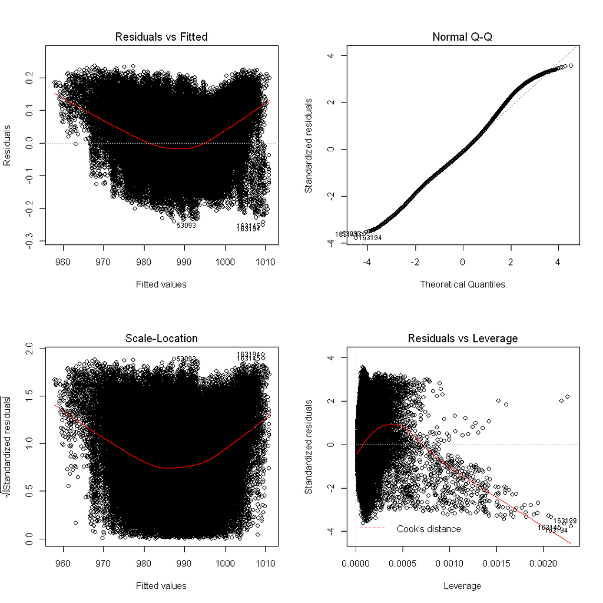

```r
options(repr.plot.width = 9, repr.plot.height = 9)
par(mfrow = c(2,2))
plot(lm_jdf_no)
```

> Well, this is evidence that my current model is quite flawed, breaking nearly every assumption. Let us check for more correlation.

```r
vif(lm_jdf_no)
kappa(lm_jdf_no)
cor(model.matrix(lm_jdf_no)[,-1])
```

**temp_c**

68864.4137287571

**temp_k**

131558.263718507

**dew_point_c**

592.094940612438

**percent_rel_humid**

72.9098230311547

**max_vapor_p_mb**

2149799.30396994

**actual_vapor_p_mb**

702944.151660255

**deficit_vapor_p_mb**

792448.13363871

**specific_humid_g_per_kg**

491829.892101569

**water_mmol_per_mol**

607770.351953443

**air_density_grams_per_cube_meter**

9525.75778606309

**wind_speed_ms**

1.18610808581413

**wind_direction_deg**

1.0470590530556

17315837.6571031

|  | temp_c | temp_k | dew_point_c | percent_rel_humid | max_vapor_p_mb | actual_vapor_p_mb | deficit_vapor_p_mb | specific_humid_g_per_kg | water_mmol_per_mol | air_density_grams_per_cube_meter | wind_speed_ms | wind_direction_deg |
| --- | --- | --- | --- | --- | --- | --- | --- | --- | --- | --- | --- | --- |
| temp_c | 1.00000000 | 0.99688558 | 0.90323894 | -0.553033720 | 0.94649233 | 0.875080939 | 0.75252002 | 0.874117765 | 0.874527914 | -0.9631651 | 0.07502572 | 0.020463769 |
| temp_k | 0.99688558 | 1.00000000 | 0.90359226 | -0.545198813 | 0.94152274 | 0.873105412 | 0.74633014 | 0.873356408 | 0.873773569 | -0.9809868 | 0.08915223 | 0.026718450 |
| dew_point_c | 0.90323894 | 0.90359226 | 1.00000000 | -0.150349971 | 0.79647680 | 0.965210164 | 0.43761252 | 0.964638575 | 0.965095425 | -0.8961368 | -0.05794999 | 0.037900445 |
| percent_rel_humid | -0.55303372 | -0.54519881 | -0.15034997 | 1.000000000 | -0.60973587 | -0.151165629 | -0.83750278 | -0.150022442 | -0.150093712 | 0.4849828 | -0.30290978 | 0.008436055 |
| max_vapor_p_mb | 0.94649233 | 0.94152274 | 0.79647680 | -0.609735866 | 1.00000000 | 0.828009718 | 0.87760475 | 0.827434278 | 0.827439019 | -0.8910259 | 0.07694095 | -0.025997272 |
| actual_vapor_p_mb | 0.87508094 | 0.87310541 | 0.96521016 | -0.151165629 | 0.82800972 | 1.000000000 | 0.45786813 | 0.999854778 | 0.999858052 | -0.8540835 | -0.08149311 | 0.005871587 |
| deficit_vapor_p_mb | 0.75252002 | 0.74633014 | 0.43761252 | -0.837502780 | 0.87760475 | 0.457868130 | 1.00000000 | 0.457079662 | 0.457084353 | -0.6825304 | 0.19166610 | -0.046236310 |
| specific_humid_g_per_kg | 0.87411776 | 0.87335641 | 0.96463857 | -0.150022442 | 0.82743428 | 0.999854778 | 0.45707966 | 1.000000000 | 0.999997381 | -0.8570377 | -0.07859440 | 0.007204019 |
| water_mmol_per_mol | 0.87452791 | 0.87377357 | 0.96509542 | -0.150093712 | 0.82743902 | 0.999858052 | 0.45708435 | 0.999997381 | 1.000000000 | -0.8574998 | -0.07849367 | 0.007421436 |
| air_density_grams_per_cube_meter | -0.96316505 | -0.98098683 | -0.89613678 | 0.484982755 | -0.89102590 | -0.854083460 | -0.68253038 | -0.857037686 | -0.857499822 | 1.0000000 | -0.11191025 | -0.044800403 |
| wind_speed_ms | 0.07502572 | 0.08915223 | -0.05794999 | -0.302909781 | 0.07694095 | -0.081493109 | 0.19166610 | -0.078594401 | -0.078493669 | -0.1119102 | 1.00000000 | -0.063436505 |
| wind_direction_deg | 0.02046377 | 0.02671845 | 0.03790044 | 0.008436055 | -0.02599727 | 0.005871587 | -0.04623631 | 0.007204019 | 0.007421436 | -0.0448004 | -0.06343651 | 1.000000000 |

```r
lm_jdf_no2 = lm(sky_p_mb ~ temp_c + dew_point_c + percent_rel_humid + max_vapor_p_mb + actual_vapor_p_mb +
            deficit_vapor_p_mb + specific_humid_g_per_kg + water_mmol_per_mol + air_density_grams_per_cube_meter +
            + wind_speed_ms + wind_direction_deg, data = jdf)
vif(lm_jdf_no2)
kappa(lm_jdf_no2)
cor(model.matrix(lm_jdf_no2)[,-1])
```

**temp_c**

574.151118183471

**dew_point_c**

415.108509430709

**percent_rel_humid**

54.6366515571287

**max_vapor_p_mb**

2533317.78747769

**actual_vapor_p_mb**

743104.91515847

**deficit_vapor_p_mb**

1007646.96364109

**specific_humid_g_per_kg**

458380.493731406

**water_mmol_per_mol**

457370.946726982

**air_density_grams_per_cube_meter**

84.1375086915226

**wind_speed_ms**

1.20413679188986

**wind_direction_deg**

1.04792138580615

468838.439787447

|  | temp_c | dew_point_c | percent_rel_humid | max_vapor_p_mb | actual_vapor_p_mb | deficit_vapor_p_mb | specific_humid_g_per_kg | water_mmol_per_mol | air_density_grams_per_cube_meter | wind_speed_ms | wind_direction_deg |
| --- | --- | --- | --- | --- | --- | --- | --- | --- | --- | --- | --- |
| temp_c | 1.00000000 | 0.90323894 | -0.553033720 | 0.94649233 | 0.875080939 | 0.75252002 | 0.874117765 | 0.874527914 | -0.9631651 | 0.07502572 | 0.020463769 |
| dew_point_c | 0.90323894 | 1.00000000 | -0.150349971 | 0.79647680 | 0.965210164 | 0.43761252 | 0.964638575 | 0.965095425 | -0.8961368 | -0.05794999 | 0.037900445 |
| percent_rel_humid | -0.55303372 | -0.15034997 | 1.000000000 | -0.60973587 | -0.151165629 | -0.83750278 | -0.150022442 | -0.150093712 | 0.4849828 | -0.30290978 | 0.008436055 |
| max_vapor_p_mb | 0.94649233 | 0.79647680 | -0.609735866 | 1.00000000 | 0.828009718 | 0.87760475 | 0.827434278 | 0.827439019 | -0.8910259 | 0.07694095 | -0.025997272 |
| actual_vapor_p_mb | 0.87508094 | 0.96521016 | -0.151165629 | 0.82800972 | 1.000000000 | 0.45786813 | 0.999854778 | 0.999858052 | -0.8540835 | -0.08149311 | 0.005871587 |
| deficit_vapor_p_mb | 0.75252002 | 0.43761252 | -0.837502780 | 0.87760475 | 0.457868130 | 1.00000000 | 0.457079662 | 0.457084353 | -0.6825304 | 0.19166610 | -0.046236310 |
| specific_humid_g_per_kg | 0.87411776 | 0.96463857 | -0.150022442 | 0.82743428 | 0.999854778 | 0.45707966 | 1.000000000 | 0.999997381 | -0.8570377 | -0.07859440 | 0.007204019 |
| water_mmol_per_mol | 0.87452791 | 0.96509542 | -0.150093712 | 0.82743902 | 0.999858052 | 0.45708435 | 0.999997381 | 1.000000000 | -0.8574998 | -0.07849367 | 0.007421436 |
| air_density_grams_per_cube_meter | -0.96316505 | -0.89613678 | 0.484982755 | -0.89102590 | -0.854083460 | -0.68253038 | -0.857037686 | -0.857499822 | 1.0000000 | -0.11191025 | -0.044800403 |
| wind_speed_ms | 0.07502572 | -0.05794999 | -0.302909781 | 0.07694095 | -0.081493109 | 0.19166610 | -0.078594401 | -0.078493669 | -0.1119102 | 1.00000000 | -0.063436505 |
| wind_direction_deg | 0.02046377 | 0.03790044 | 0.008436055 | -0.02599727 | 0.005871587 | -0.04623631 | 0.007204019 | 0.007421436 | -0.0448004 | -0.06343651 | 1.000000000 |

> That helped a little, let me see if I can get rid of any other collinearity problems.

```r
lm_jdf_no3 = lm(sky_p_mb ~ temp_c + percent_rel_humid + max_vapor_p_mb + actual_vapor_p_mb +
            deficit_vapor_p_mb + specific_humid_g_per_kg + water_mmol_per_mol + air_density_grams_per_cube_meter +
            + wind_speed_ms + wind_direction_deg, data = jdf)
vif(lm_jdf_no3)
kappa(lm_jdf_no3)
cor(model.matrix(lm_jdf_no3)[,-1])
```

**temp_c**

173.84684608453

**percent_rel_humid**

9.76455662796908

**max_vapor_p_mb**

2533275.5082445

**actual_vapor_p_mb**

742650.42922611

**deficit_vapor_p_mb**

1007594.67273176

**specific_humid_g_per_kg**

434208.167884287

**water_mmol_per_mol**

439439.426491351

**air_density_grams_per_cube_meter**

81.6493802226997

**wind_speed_ms**

1.19599142338876

**wind_direction_deg**

1.04198035328449

561690.642918637

|  | temp_c | percent_rel_humid | max_vapor_p_mb | actual_vapor_p_mb | deficit_vapor_p_mb | specific_humid_g_per_kg | water_mmol_per_mol | air_density_grams_per_cube_meter | wind_speed_ms | wind_direction_deg |
| --- | --- | --- | --- | --- | --- | --- | --- | --- | --- | --- |
| temp_c | 1.00000000 | -0.553033720 | 0.94649233 | 0.875080939 | 0.75252002 | 0.874117765 | 0.874527914 | -0.9631651 | 0.07502572 | 0.020463769 |
| percent_rel_humid | -0.55303372 | 1.000000000 | -0.60973587 | -0.151165629 | -0.83750278 | -0.150022442 | -0.150093712 | 0.4849828 | -0.30290978 | 0.008436055 |
| max_vapor_p_mb | 0.94649233 | -0.609735866 | 1.00000000 | 0.828009718 | 0.87760475 | 0.827434278 | 0.827439019 | -0.8910259 | 0.07694095 | -0.025997272 |
| actual_vapor_p_mb | 0.87508094 | -0.151165629 | 0.82800972 | 1.000000000 | 0.45786813 | 0.999854778 | 0.999858052 | -0.8540835 | -0.08149311 | 0.005871587 |
| deficit_vapor_p_mb | 0.75252002 | -0.837502780 | 0.87760475 | 0.457868130 | 1.00000000 | 0.457079662 | 0.457084353 | -0.6825304 | 0.19166610 | -0.046236310 |
| specific_humid_g_per_kg | 0.87411776 | -0.150022442 | 0.82743428 | 0.999854778 | 0.45707966 | 1.000000000 | 0.999997381 | -0.8570377 | -0.07859440 | 0.007204019 |
| water_mmol_per_mol | 0.87452791 | -0.150093712 | 0.82743902 | 0.999858052 | 0.45708435 | 0.999997381 | 1.000000000 | -0.8574998 | -0.07849367 | 0.007421436 |
| air_density_grams_per_cube_meter | -0.96316505 | 0.484982755 | -0.89102590 | -0.854083460 | -0.68253038 | -0.857037686 | -0.857499822 | 1.0000000 | -0.11191025 | -0.044800403 |
| wind_speed_ms | 0.07502572 | -0.302909781 | 0.07694095 | -0.081493109 | 0.19166610 | -0.078594401 | -0.078493669 | -0.1119102 | 1.00000000 | -0.063436505 |
| wind_direction_deg | 0.02046377 | 0.008436055 | -0.02599727 | 0.005871587 | -0.04623631 | 0.007204019 | 0.007421436 | -0.0448004 | -0.06343651 | 1.000000000 |

> That helped the temp_c variable a ton!

```r
lm_jdf_no4 = lm(sky_p_mb ~ temp_c + percent_rel_humid + actual_vapor_p_mb +
            deficit_vapor_p_mb + specific_humid_g_per_kg + water_mmol_per_mol + air_density_grams_per_cube_meter +
            + wind_speed_ms + wind_direction_deg, data = jdf)
vif(lm_jdf_no4)
kappa(lm_jdf_no4)
cor(model.matrix(lm_jdf_no4)[,-1])
```

**temp_c**

173.410484656685

**percent_rel_humid**

9.76269527423228

**actual_vapor_p_mb**

19524.551489088

**deficit_vapor_p_mb**

6.93080331397014

**specific_humid_g_per_kg**

434203.446453689

**water_mmol_per_mol**

439408.319634584

**air_density_grams_per_cube_meter**

81.4203288264222

**wind_speed_ms**

1.19594984880906

**wind_direction_deg**

1.04189078341825

426170.864785903

|  | temp_c | percent_rel_humid | actual_vapor_p_mb | deficit_vapor_p_mb | specific_humid_g_per_kg | water_mmol_per_mol | air_density_grams_per_cube_meter | wind_speed_ms | wind_direction_deg |
| --- | --- | --- | --- | --- | --- | --- | --- | --- | --- |
| temp_c | 1.00000000 | -0.553033720 | 0.875080939 | 0.75252002 | 0.874117765 | 0.874527914 | -0.9631651 | 0.07502572 | 0.020463769 |
| percent_rel_humid | -0.55303372 | 1.000000000 | -0.151165629 | -0.83750278 | -0.150022442 | -0.150093712 | 0.4849828 | -0.30290978 | 0.008436055 |
| actual_vapor_p_mb | 0.87508094 | -0.151165629 | 1.000000000 | 0.45786813 | 0.999854778 | 0.999858052 | -0.8540835 | -0.08149311 | 0.005871587 |
| deficit_vapor_p_mb | 0.75252002 | -0.837502780 | 0.457868130 | 1.00000000 | 0.457079662 | 0.457084353 | -0.6825304 | 0.19166610 | -0.046236310 |
| specific_humid_g_per_kg | 0.87411776 | -0.150022442 | 0.999854778 | 0.45707966 | 1.000000000 | 0.999997381 | -0.8570377 | -0.07859440 | 0.007204019 |
| water_mmol_per_mol | 0.87452791 | -0.150093712 | 0.999858052 | 0.45708435 | 0.999997381 | 1.000000000 | -0.8574998 | -0.07849367 | 0.007421436 |
| air_density_grams_per_cube_meter | -0.96316505 | 0.484982755 | -0.854083460 | -0.68253038 | -0.857037686 | -0.857499822 | 1.0000000 | -0.11191025 | -0.044800403 |
| wind_speed_ms | 0.07502572 | -0.302909781 | -0.081493109 | 0.19166610 | -0.078594401 | -0.078493669 | -0.1119102 | 1.00000000 | -0.063436505 |
| wind_direction_deg | 0.02046377 | 0.008436055 | 0.005871587 | -0.04623631 | 0.007204019 | 0.007421436 | -0.0448004 | -0.06343651 | 1.000000000 |

> That is our lowest kappa yet! We can keep going, a somewhat decent model may be in our grasp!

```r
lm_jdf_no5 =  lm(sky_p_mb ~ temp_c + percent_rel_humid + actual_vapor_p_mb +
            deficit_vapor_p_mb + specific_humid_g_per_kg + water_mmol_per_mol +
            + wind_speed_ms + wind_direction_deg, data = jdf)
vif(lm_jdf_no5)
kappa(lm_jdf_no5)
cor(model.matrix(lm_jdf_no5)[,-1])
```

**temp_c**

44.5287235381757

**percent_rel_humid**

9.03907810362796

**actual_vapor_p_mb**

3777.97280532594

**deficit_vapor_p_mb**

6.27893423180019

**specific_humid_g_per_kg**

430144.316554475

**water_mmol_per_mol**

435800.180786525

**wind_speed_ms**

1.19181911939201

**wind_direction_deg**

1.04056096975912

100889.352824959

|  | temp_c | percent_rel_humid | actual_vapor_p_mb | deficit_vapor_p_mb | specific_humid_g_per_kg | water_mmol_per_mol | wind_speed_ms | wind_direction_deg |
| --- | --- | --- | --- | --- | --- | --- | --- | --- |
| temp_c | 1.00000000 | -0.553033720 | 0.875080939 | 0.75252002 | 0.874117765 | 0.874527914 | 0.07502572 | 0.020463769 |
| percent_rel_humid | -0.55303372 | 1.000000000 | -0.151165629 | -0.83750278 | -0.150022442 | -0.150093712 | -0.30290978 | 0.008436055 |
| actual_vapor_p_mb | 0.87508094 | -0.151165629 | 1.000000000 | 0.45786813 | 0.999854778 | 0.999858052 | -0.08149311 | 0.005871587 |
| deficit_vapor_p_mb | 0.75252002 | -0.837502780 | 0.457868130 | 1.00000000 | 0.457079662 | 0.457084353 | 0.19166610 | -0.046236310 |
| specific_humid_g_per_kg | 0.87411776 | -0.150022442 | 0.999854778 | 0.45707966 | 1.000000000 | 0.999997381 | -0.07859440 | 0.007204019 |
| water_mmol_per_mol | 0.87452791 | -0.150093712 | 0.999858052 | 0.45708435 | 0.999997381 | 1.000000000 | -0.07849367 | 0.007421436 |
| wind_speed_ms | 0.07502572 | -0.302909781 | -0.081493109 | 0.19166610 | -0.078594401 | -0.078493669 | 1.00000000 | -0.063436505 |
| wind_direction_deg | 0.02046377 | 0.008436055 | 0.005871587 | -0.04623631 | 0.007204019 | 0.007421436 | -0.06343651 | 1.000000000 |

```r
lm_jdf_no6 = lm(sky_p_mb ~ temp_c + percent_rel_humid +
            deficit_vapor_p_mb + specific_humid_g_per_kg + water_mmol_per_mol +
            + wind_speed_ms + wind_direction_deg, data = jdf)
vif(lm_jdf_no6)
kappa(lm_jdf_no6)
cor(model.matrix(lm_jdf_no6)[,-1])
```

**temp_c**

44.2392978267961

**percent_rel_humid**

9.03888163887077

**deficit_vapor_p_mb**

6.26343349680987

**specific_humid_g_per_kg**

429536.50020213

**water_mmol_per_mol**

434477.505273791

**wind_speed_ms**

1.13183967054239

**wind_direction_deg**

1.02644758755388

104356.541186845

|  | temp_c | percent_rel_humid | deficit_vapor_p_mb | specific_humid_g_per_kg | water_mmol_per_mol | wind_speed_ms | wind_direction_deg |
| --- | --- | --- | --- | --- | --- | --- | --- |
| temp_c | 1.00000000 | -0.553033720 | 0.75252002 | 0.874117765 | 0.874527914 | 0.07502572 | 0.020463769 |
| percent_rel_humid | -0.55303372 | 1.000000000 | -0.83750278 | -0.150022442 | -0.150093712 | -0.30290978 | 0.008436055 |
| deficit_vapor_p_mb | 0.75252002 | -0.837502780 | 1.00000000 | 0.457079662 | 0.457084353 | 0.19166610 | -0.046236310 |
| specific_humid_g_per_kg | 0.87411776 | -0.150022442 | 0.45707966 | 1.000000000 | 0.999997381 | -0.07859440 | 0.007204019 |
| water_mmol_per_mol | 0.87452791 | -0.150093712 | 0.45708435 | 0.999997381 | 1.000000000 | -0.07849367 | 0.007421436 |
| wind_speed_ms | 0.07502572 | -0.302909781 | 0.19166610 | -0.078594401 | -0.078493669 | 1.00000000 | -0.063436505 |
| wind_direction_deg | 0.02046377 | 0.008436055 | -0.04623631 | 0.007204019 | 0.007421436 | -0.06343651 | 1.000000000 |

```r
lm_jdf_no7 = lm(sky_p_mb ~ temp_c + percent_rel_humid +
            deficit_vapor_p_mb + water_mmol_per_mol +
            + wind_speed_ms + wind_direction_deg, data = jdf)
vif(lm_jdf_no7)
kappa(lm_jdf_no7)
cor(model.matrix(lm_jdf_no7)[,-1])
```

**temp_c**

19.9367486863765

**percent_rel_humid**

6.78641277785995

**deficit_vapor_p_mb**

5.72308975777635

**water_mmol_per_mol**

13.4962399348206

**wind_speed_ms**

1.13183839636804

**wind_direction_deg**

1.0259318129367

1632.37004564234

|  | temp_c | percent_rel_humid | deficit_vapor_p_mb | water_mmol_per_mol | wind_speed_ms | wind_direction_deg |
| --- | --- | --- | --- | --- | --- | --- |
| temp_c | 1.00000000 | -0.553033720 | 0.75252002 | 0.874527914 | 0.07502572 | 0.020463769 |
| percent_rel_humid | -0.55303372 | 1.000000000 | -0.83750278 | -0.150093712 | -0.30290978 | 0.008436055 |
| deficit_vapor_p_mb | 0.75252002 | -0.837502780 | 1.00000000 | 0.457084353 | 0.19166610 | -0.046236310 |
| water_mmol_per_mol | 0.87452791 | -0.150093712 | 0.45708435 | 1.000000000 | -0.07849367 | 0.007421436 |
| wind_speed_ms | 0.07502572 | -0.302909781 | 0.19166610 | -0.078493669 | 1.00000000 | -0.063436505 |
| wind_direction_deg | 0.02046377 | 0.008436055 | -0.04623631 | 0.007421436 | -0.06343651 | 1.000000000 |

> Sweet, our kappa has gone from 13 million to under 1675.

```r
lm_jdf_no8 = lm(sky_p_mb ~ temp_c + percent_rel_humid +
            deficit_vapor_p_mb +
            + wind_speed_ms + wind_direction_deg, data = jdf)
vif(lm_jdf_no8)
kappa(lm_jdf_no8)
cor(model.matrix(lm_jdf_no8)[,-1])
```

**temp_c**

2.44576872132798

**percent_rel_humid**

3.77495169208073

**deficit_vapor_p_mb**

5.72308221572348

**wind_speed_ms**

1.12529076273785

**wind_direction_deg**

1.01981354171417

1605.87936489027

|  | temp_c | percent_rel_humid | deficit_vapor_p_mb | wind_speed_ms | wind_direction_deg |
| --- | --- | --- | --- | --- | --- |
| temp_c | 1.00000000 | -0.553033720 | 0.75252002 | 0.07502572 | 0.020463769 |
| percent_rel_humid | -0.55303372 | 1.000000000 | -0.83750278 | -0.30290978 | 0.008436055 |
| deficit_vapor_p_mb | 0.75252002 | -0.837502780 | 1.00000000 | 0.19166610 | -0.046236310 |
| wind_speed_ms | 0.07502572 | -0.302909781 | 0.19166610 | 1.00000000 | -0.063436505 |
| wind_direction_deg | 0.02046377 | 0.008436055 | -0.04623631 | -0.06343651 | 1.000000000 |

```r
lm_jdf_no9 = lm(sky_p_mb ~ temp_c + percent_rel_humid
            + wind_speed_ms + wind_direction_deg, data = jdf)
vif(lm_jdf_no9)
kappa(lm_jdf_no9)
cor(model.matrix(lm_jdf_no9)[,-1])
```

**temp_c**

1.46118814297464

**percent_rel_humid**

1.59892476754174

**wind_speed_ms**

1.12031268587705

**wind_direction_deg**

1.00469737820639

1193.65490328841

|  | temp_c | percent_rel_humid | wind_speed_ms | wind_direction_deg |
| --- | --- | --- | --- | --- |
| temp_c | 1.00000000 | -0.553033720 | 0.07502572 | 0.020463769 |
| percent_rel_humid | -0.55303372 | 1.000000000 | -0.30290978 | 0.008436055 |
| wind_speed_ms | 0.07502572 | -0.302909781 | 1.00000000 | -0.063436505 |
| wind_direction_deg | 0.02046377 | 0.008436055 | -0.06343651 | 1.000000000 |

```r
lm_jdf_no10 = lm(sky_p_mb ~
                 temp_c + wind_speed_ms + wind_direction_deg,
                 data = jdf)
vif(lm_jdf_no10)
kappa(lm_jdf_no10)
cor(model.matrix(lm_jdf_no10)[,-1])
```

**temp_c**

1.00630716753479

**wind_speed_ms**

1.00994999132062

**wind_direction_deg**

1.00468585307964

459.127029042649

|  | temp_c | wind_speed_ms | wind_direction_deg |
| --- | --- | --- | --- |
| temp_c | 1.00000000 | 0.07502572 | 0.02046377 |
| wind_speed_ms | 0.07502572 | 1.00000000 | -0.06343651 |
| wind_direction_deg | 0.02046377 | -0.06343651 | 1.00000000 |

Although the kappa is still over 400, which is quite large, we have come a long way from 13 million. Let's check if this model violations the assumptions like the first.

```r
lm_jdf_final = lm(sky_p_mb ~
                 temp_c + wind_speed_ms + wind_direction_deg,
                 data = jdf)
summary(lm_jdf_final)
```

```
Call:
lm(formula = sky_p_mb ~ temp_c + wind_speed_ms + wind_direction_deg,
    data = jdf)

Residuals:
    Min      1Q  Median      3Q     Max
-73.694  -4.916   0.277   5.508  23.528

Coefficients:
                     Estimate Std. Error   t value Pr(>|t|)
(Intercept)         9.930e+02  5.875e-02 16902.850  < 2e-16 ***
temp_c             -1.697e-02  2.367e-03    -7.167 7.69e-13 ***
wind_speed_ms      -1.028e+00  1.323e-02   -77.715  < 2e-16 ***
wind_direction_deg -8.960e-03  2.373e-04   -37.755  < 2e-16 ***
---
Signif. codes:  0 '***' 0.001 '**' 0.01 '*' 0.05 '.' 0.1 ' ' 1

Residual standard error: 8.351 on 166026 degrees of freedom
Multiple R-squared:  0.04214,	Adjusted R-squared:  0.04212
F-statistic:  2435 on 3 and 166026 DF,  p-value: < 2.2e-16
```

```r
w <- abs(rstudent(lm_jdf_final)) < 3 & abs(cooks.distance(lm_jdf_final)) < 4/nrow(lm_jdf_final$model)
lm_jdf_final <- update(lm_jdf_final, weights=as.numeric(w))
```

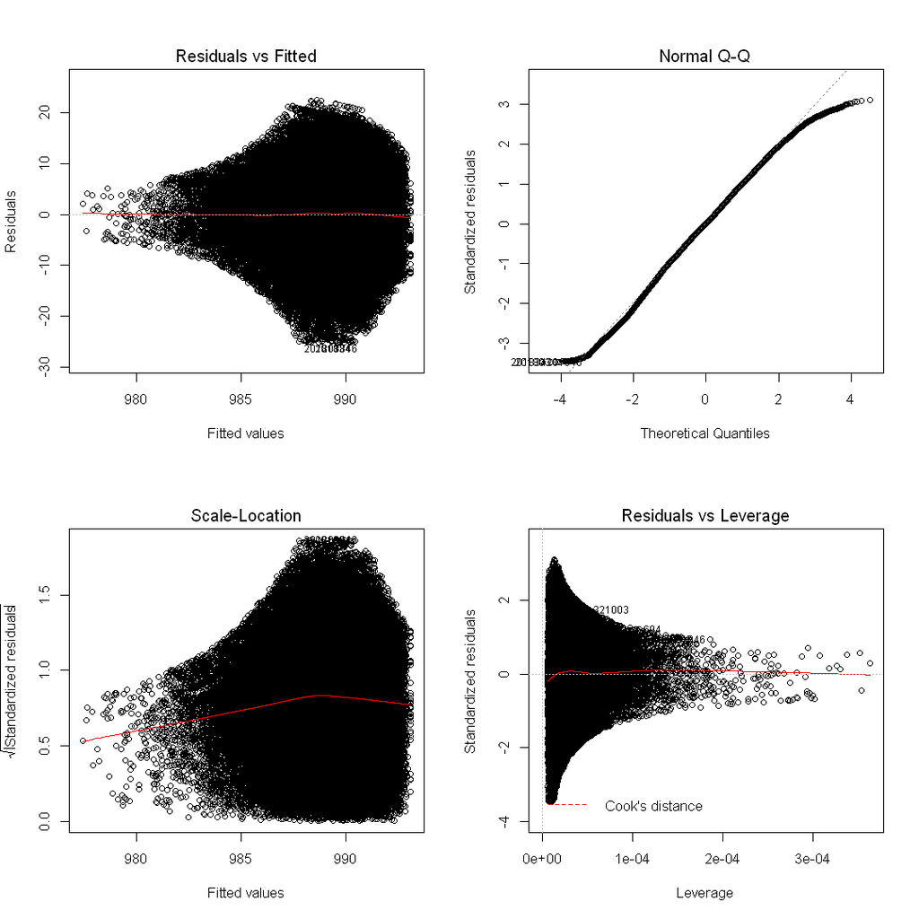

```r
options(repr.plot.width = 9, repr.plot.height = 9)
par(mfrow = c(2,2))
plot(lm_jdf_final)
```

```r
n = dim(jdf)[1]; n
```

166030

```r
data_ts <- xts(jdf$sky_p_mb, jdf$time, tz = "Europe/Berlin")        # Convert data frame to time series
```

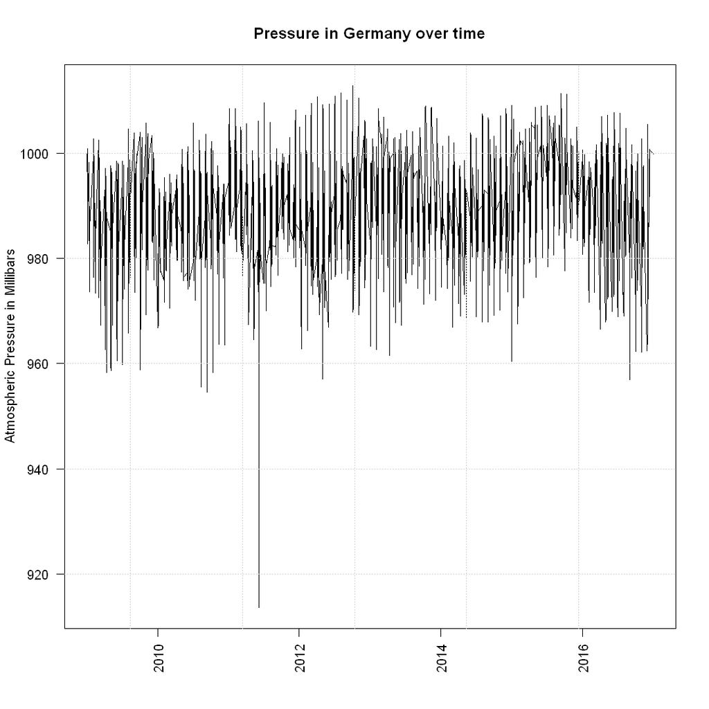

```r
zoo::plot.zoo(data_ts, screens = 1, xlab="", las=2, ylab = "Atmospheric Pressure in Millibars",
              main ="Pressure in Germany over time")
grid() # add the grid
```

```r
t.ser <- ts(jdf$sky_p_mb, start=c(2009,1), freq=12)
t.ets <- ets(t.ser)
t.fc <- forecast(t.ets,h=120000)
```

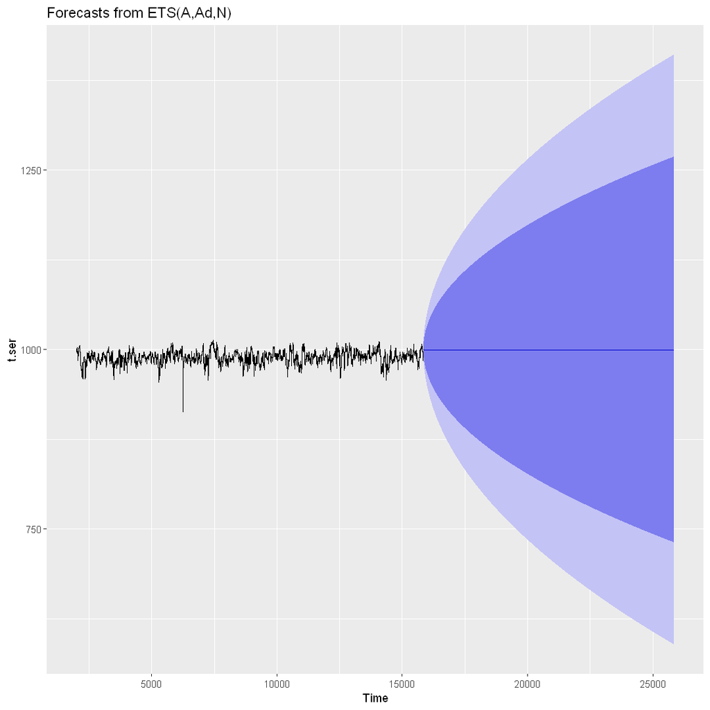

```r
autoplot(t.fc)
```